# 161.307: Assignment 2

## Exercise 2

### Part 1: Purpose of the wrangling code

*(no more than 3 sentences)*

First, the raw graph data is wrangled to have one row per unique edge using `count()` (AKA single weighted edge pair), which is effectively `group_by(to, from) %>% summarise(weight = n())` and shows us if a student has a friend in one or both years (weight 1 and weight 2 respectively).  
Next the data is converted to an object tidygraph can use, which treats relationships as symmetric (not directed), so we are assuming friendship is mutual.  
Lastly it creates degree as the number of connections each node has using `centrality_degree()`, which gives the ability to visualise how each student (node) has rated their friends over the two years of interest.

### Part 2: Reproduce the chart

```r
data(highschool, package = "ggraph")

edge_weights <- highschool |>
  count(from, to, name = "weight")

g <- as_tbl_graph(edge_weights, directed = FALSE) |>
  activate(nodes) |>
  mutate(degree = centrality_degree())
```

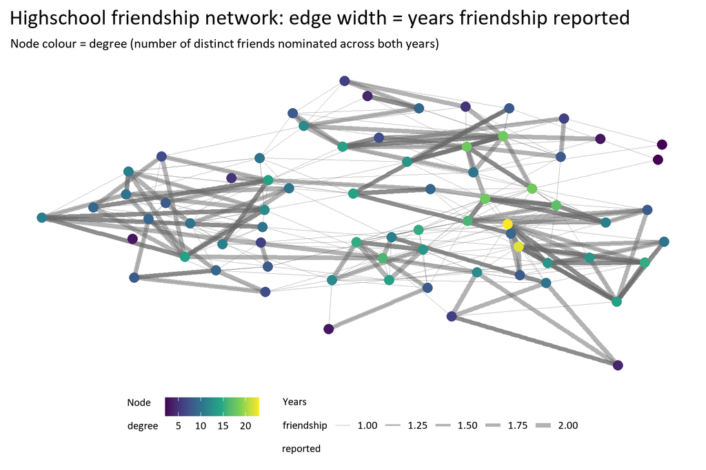

```r
# approach: trial and error!
set.seed(161307)
ggraph(g, layout = "kk") +
  geom_edge_link(aes(width = weight), alpha = 0.5, color = "#676767") + #used a colour picker
  #control size of the lines
  scale_edge_width(range = c(0.3, 2)) +
  geom_node_point(aes(colour = degree), size = 4) +
  #Scale commands
  scale_colour_viridis_c() +
  #labels
  labs(
    title = "Highschool friendship network: edge width = years friendship reported",
    subtitle = "Node colour = degree (number of distinct friends nominated across both years)",
    colour = "Node\ndegree",
    edge_width = "Years\nfriendship\nreported",
  ) +
    #guides ordering
  guides(
    colour = guide_colorbar(order = 1),
    edge_width = guide_legend(order = 2)
  ) +
  # themes
    #Font looks like calibri?.
  theme_graph(base_family = "Calibri") +
  theme(
    legend.position = "bottom",
    legend.title = element_text(size = 20),
    legend.text = element_text(size = 20),
    plot.margin = margin(10,10,10,10),
    plot.title = element_text(size = 40, face = 'plain'),
    plot.subtitle = element_text(size = 25, margin = margin(t=0, b=15))
  )
```

## Exercise 3

```r
student_id <- 49
set.seed(student_id)

n <- sample(40:80, 1) #7-
model_choice <- student_id %% 3

g <- switch(model_choice + 1,
  play_erdos_renyi(n, p = runif(1, 0.03, 0.08), directed = FALSE),
  play_barabasi_albert(n, power = runif(1, 0.8, 1.5), directed = FALSE), #this is my one
  play_smallworld(n_dim = 1, dim_size = n, order = 3, p = runif(1, 0.01, 0.05))
) |>
  activate(nodes) |>
  mutate(degree = centrality_degree(),
         betweenness = centrality_betweenness(directed = FALSE),
         ) |>
  activate(edges) |>
  mutate(edge_betweenness = centrality_edge_betweenness(directed = FALSE))
```

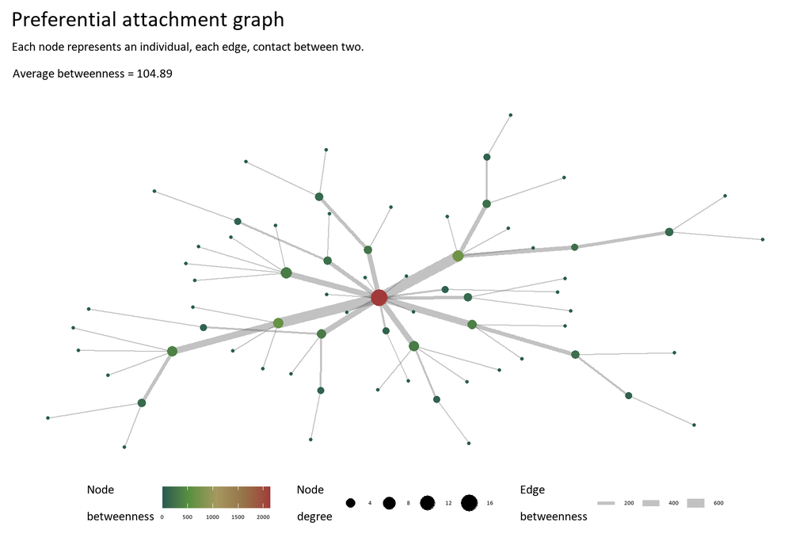

```r
#stress and KK were similar in look, but kk is the easier one to read.
#try directed, try weights on edges.
#this chart is not required for the assessment, but I think it is helpful for the discussion
ggraph(g, layout = "kk") +
  geom_edge_link(aes(width = edge_betweenness), alpha = 0.4, color = "#676767") +
  scale_edge_width(range = c(0.5, 4),
                   name = 'Edge\nbetweenness') +
  geom_node_point(aes(colour = betweenness, size = degree)) +
  #Scale commands
  scale_colour_gradientn(colours = rev(custom_palette)) +
  #labels
  labs(
    title = "Preferential attachment graph",
    subtitle = paste0("Each node represents an individual, each edge, contact between two.\nAverage betweenness = ",
                      round(mean(betweenness(g, directed = FALSE)),2)),
    size = "Node\ndegree",
    colour = "Node\nbetweenness"
  ) +
  # guides ordering
  guides(
    colour = guide_colorbar(order = 1),
    size = guide_legend(order = 2),
    width = guide_legend(order = 3)
  ) +
  # themes
  theme_graph(base_family = "Calibri") +
  theme(
    legend.position = "bottom",
    legend.title = element_text(size = 20),
    legend.text = element_text(size = 10),
    plot.margin = margin(10,10,10,10),
    plot.title = element_text(size = 35, face = 'plain'),
    plot.subtitle = element_text(size = 20, margin = margin(t=0, b=15))
  )
```

### Question

How does mean betweenness of this graph’s node attachment vary under resampling?.

### Approach

To analyse the summary statistic parametric resampling will be applied - recreating the graph using the same parameters. This is the appropriate choice because with a Barabasi-Albert graph, the final graph is the end result of a stochastic process which grows stepwise through time. A process of preferential attachment. Resampling the same graph/nodes with replacement would be to undo the preferential attachment structure. The uncertainty of interest is the model uncertainty, i.e. how much the mean betweenness varies across the same Barabasi-Albert process, not the betweenness from the observed final dataset. Because the resampling process used is frequentist, the uncertainty is best shown with confidence intervals. Because the graph is a process of sequential attachment, a ribbon plot showing betweenness as nodes are attached will reflect both the summary statistic and the structure of the graph. Next to this a raincloud chart can show the overall shape of the mean betweenness for each replicate graph. Beneath this a ridge-line plot can show the betweenness distribution as each node is added across all replicates, allowing analysis of how the betweenness score’s distribution changes with the structure of the graph. A single chart would not reveal as much about the structural link between the graph and the betweenness value.

### Analysis

```r
#Replicate the graph process B time for a graph with n nodes.
#Keep all the graph data, calculate the statistic for betweenness. Return as tibble.
#use this to visualise charts to show structure of the BA graph.

Q3_data <- function(n, B = 1000) {
  lapply(seq_len(B), function(i) {
    #create graph process
    graph_model <- play_barabasi_albert(n, power = runif(1, 0.8, 1.5), directed = FALSE)

    graph_model %>%
      activate(nodes) %>%
      mutate(node_id = 1:n, #get node ID for visualisation
             betweenness = centrality_betweenness(directed = FALSE),
             replication = i) %>%
      as_tibble() %>%
      select(replication, node_id, betweenness)
  }) %>%
    bind_rows()
}

#create the dataset, using n from the graph setup
Q3_graph_data <- Q3_data(n, B = 1000)

#wrangle data set for the ribbon
ribbon_data <- Q3_graph_data %>%
  group_by(node_id) %>%
  reframe( #gor a warning using summarise
    mean   = mean(betweenness),
    .width = c(0.5, 0.8, 0.95),
    .lower = c(quantile(betweenness, 0.25),
               quantile(betweenness, 0.10),
               quantile(betweenness, 0.025)),
    .upper = c(quantile(betweenness, 0.75),
               quantile(betweenness, 0.90),
               quantile(betweenness, 0.975)),
    .groups = 'drop'
  ) %>%
  mutate(.width = factor(.width, levels = c(0.5, 0.8, 0.95)))
```

[figure not shown]

```r
#I want to look at the summary stat as per hte question, but I also want to see
#how the summary stat varies structurally. BA graphs are "ordered" you could say.
#Nodes are sequentially attached to the graph, so the noe number is a proxy for
#how long it has been in the graph, and therefore the node's betweenness will
#likely reflect that.

#===== Rain cloud chart =====#
widths = c(0.5, 0.8, 0.95)

#set up geoms
rain <- Q3_graph_data %>%
  group_by(replication) %>%
  summarise(betweenness = mean(betweenness)) %>%
  #graph geoms
    #hdensity
  ggplot(aes(x = 0, y = betweenness)) +
  stat_halfeye(
    mapping = aes(fill_ramp = after_stat(level)),
    fill_type = "segments",
    .width = widths,
    show.legend = c(size = FALSE, fill_ramp = TRUE),
    col = NA,
    fill = "#5a903f",
  ) +
    #make it rain!
  stat_dotsinterval(
    mapping = aes(fill_ramp = after_stat(level)),
    .width = widths,
    side = 'bottom',
    layout = 'bin',
    slab_linewidth = NA,
    col = NA,
    fill = "#5a903f",
    show.legend = FALSE,
    quantiles = 200 #each dot is 5 units
  ) +
    #add a dot at the mean
  stat_summary(geom = "point", fun = mean, col = '#18171e', size = 3) +
  #scale commands
    #colour & legend
  scale_fill_ramp_discrete(
    from = "white",
    na.translate = FALSE
  ) +
  guides(fill = "none", fill_ramp = guide_legend(title = "Confidence interval")) +
    # axis
  scale_y_continuous(
    breaks = seq(
      from = 40,
      to = 200,
      by = 20),
    limits = c(40, 220)
  ) +
  #labels
  labs(
    title = '',
    subtitle = 'The distribution of mean betweenness\napproximates a normal distribution.',
    y = "Mean Betweenness",
    x = ""
  ) +
  #themes
  theme_minimal(base_family = "Calibri") +
  theme(
    plot.subtitle = element_text(size = 30),
    axis.text.y = element_text(size = 20),
    axis.title.y = element_text(size = 20),
    axis.text.x = element_blank(),
    legend.position = 'top',
    legend.title = element_text(size = 20),
    legend.text = element_text(size = 20),
    panel.grid.major.x = element_blank(),
    panel.grid.minor.x = element_blank(),
  )


#===== Ribbon Chart =====#
#set up geoms
ribbon <- ggplot(ribbon_data, aes(x = node_id, y = mean, ymin = .lower, ymax = .upper)) +
  geom_lineribbon(aes(fill = .width),
                  alpha = 0.4,
                  colour = NA) +
  geom_line(aes(y= mean, colour = "Mean betweenness"), linewidth = 1) +
  #Scale commands
  scale_fill_manual(values = c('0.5' = "#5A903F",
                               '0.8' = "#9CBC8C",
                               '0.95' = "#DEE9D9"),
                    guide = 'none') + #will use the rain cloud legend
  scale_colour_manual(values = c("Mean betweenness" = "#a13939"), name = NULL) +

  #axis
  scale_x_continuous(
    breaks = seq(
    from = 0,
    to = max(Q3_graph_data$node_id),
    by = 5),
    expand = expansion(mult = 0, add = 0)
  ) +
  scale_y_continuous(
    breaks = seq(
    from = 0,
    to = max(Q3_graph_data$betweenness),
    by = 100),
    expand = expansion(mult = 0, add = 0)
  ) +
  #labels
  labs(
    title = "",
    subtitle = "As new individuals interact, fewer paths traverse them,\nbetweenness tends to zero, and the confidence interval narrows towards zero.",
    x = "Node (attachment order)",
    y = "Betweenness",
    ) +
  #theme
  theme_minimal(base_family = 'Calibri') +
  theme(
    legend.position = 'top',
    legend.justification = 'left',
    legend.title = element_text(size = 20),
    legend.text = element_text(size = 20),
    plot.subtitle = element_text(size = 30),
    axis.title.x = element_text(size = 20),
    axis.title.y = element_text(size = 20),
    axis.text.x = element_text(size = 20),
    axis.text.y = element_text(size = 20),

  )

#===== Ridgeline =====#
ridgeline <- Q3_graph_data %>%
  mutate(node_id = factor(node_id)) %>%
  filter(node_id %in% c(1,5,10,15,20,25,30,35,40,45,50,55,60,65,70)) %>%
  ggplot(aes(x = betweenness/1000, y = node_id, fill = ..x..)) +
  geom_density_ridges_gradient(scale = 10,
                               rel_min_height = 0.01) +
  #scale commands
  scale_fill_gradientn(colours = c("#a13939", "#285c50", "#5a903f", "#9CBC8C", "#DEE9D9")) +
  scale_y_discrete(breaks = c("1", "10", "20", "30", "40", "50", "60", "70")) +
  #labels
  labs(fill = 'Betweenness',
       title = "",
       subtitle = "Increasing node attachment drives the graph betweenness distribution towards a narrow, peaked normal distribution.",
       y = "Node attachment",
       x = "Betweenness (thousands)") +
  theme_minimal(base_family = "Calibri") +
  theme(legend.position = 'top',
        legend.title = element_text(size = 20),
        legend.text = element_text(size = 20),
        plot.subtitle = element_text(size = 30),
        panel.grid.major.x = element_blank(),
        panel.grid.minor.x = element_blank(),
        axis.title.x = element_text(size = 20),
        axis.title.y = element_text(size = 20),
        axis.text.x = element_text(size = 20),
        axis.text.y = element_text(size = 20),)

#===== Patchwork Output=====#
(rain + ribbon + plot_layout(widths = c(0.3, 0.7))) / ridgeline +
  plot_layout(heights = c(1.5, 1)) +
  plot_annotation(title = "Preferential attachment graph node betweenness from 1000 replications") &
  theme(plot.title = element_text(family = "Calibri", size = 40))
```

## Reflection

1. *(Which of simulation/uncertainty/network thinking did you find hardest, and why?)* None. I have studied each before and like them all, so the combination of them all was joyful. It brought back fond memories of the Bayesian course Matthieu taught, which was far and away the best course I have done. From an implementation of the thinking in code, resampling was the hardest. Simply because of the syntax. Here, in this assessment I ended up using lapply rather than replicate to get the resampling outcome I wanted. And figuring out which type of resampling to do for the process was a puzzle, but that doesn’t mean it was hard, just enjoyable.
2. *(An example where seeing the full distribution changed your interpretation, vs a “dynamite plot”)* I get the sense that dynamite plots are in the same category as pie charts… so I haven’t really been looking at many. The primary example that comes to mind is the one from lecture 6. Which was hardly revelatory. I do vaguely recall seeing one in a journal of medical science about psychiatry on the base rates of autism in the population over time. Diagnosis followed the DSM5 criteria. Which hadn’t changed more than population growth would account for. This was about 2 years ago. Box plots for the same data were more revealing. At that point I wasn’t thinking about this question though. So I wasn’t being critical about the dynamite graph, I only thought it was kind of pointless and a table would have been just as good. In general, I suppose that were I to look at the dynamite plot, I’d compare it to other columns in the same chart and think of quantity. Depending on the scale, a small difference may visually appear large, and the narrower error bar would imply more accurate estimates. However, on that information alone, I may interpret that a large change has occurred. When seeing the distribution I may see that the means are closer than normal, and the shift is due to a tightening or widening of the sample range, more outliers, more point estimates or so on. So the main thing I’d realise is that the dynamite plot is not about quantity, and this would confuse me, since column charts are usually about counts by group.
3. *(Which Weeks 5-7 concept would you like to understand more deeply, and why?)* I could go in for networks all day. I think they are very interesting and full of Hungarian mathematicians, which is only a good thing. I have studied them briefly in Algebra, a little in artificial intelligence and machine learning with respect to solving puzzles and neural networks. I am familiar with the concept of a graph (and at work I sometimes get to play with neo4j, which is fun), but not the various species. Knowing more about them would be great! I’d take a whole paper on it! Why, specifically? They present another way to approach and solve problems which is another string to the bow. My interest is purely of the abstract kind. I don’t care about the practical applications. They are interesting and fun. Which probably makes me sound dull… I have other hobbies I swear!